# Assignment 3: Github Project

### Top 10 Countries by Medal Count

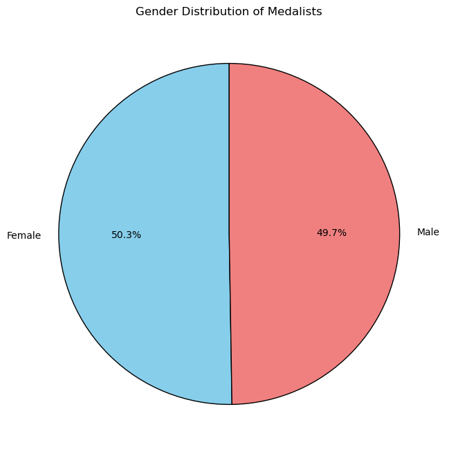

```python
## Gender Distribution of Medalists
gender_distribution = data["gender"].value_counts()

plt.figure(figsize=(8, 8))
plt.pie(
    gender_distribution,
    labels=gender_distribution.index,
    autopct="%1.1f%%",
    startangle=90,
    colors=["skyblue", "lightcoral"],
    wedgeprops={"edgecolor": "black"})
plt.title("Gender Distribution of Medalists")
plt.show()
```

### Gender Distribution of Medalists

The pie chart shows that the distribution of male and female medalists is nearly equal, with 50.3% female and 49.7% male athletes. This reflects progress toward achieving gender equality in sports.

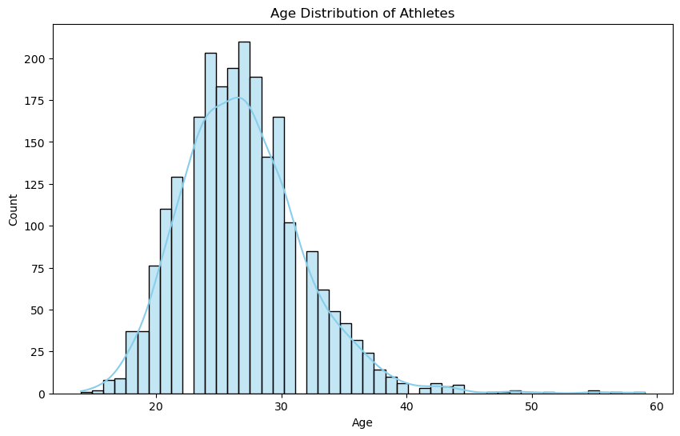

```python
## Age Distribution of Athletes

plt.figure(figsize=(10, 6))
sns.histplot(data["age"].dropna(), kde=True, color="skyblue", edgecolor="black")
plt.xlabel("Age")
plt.ylabel("Count")
plt.title("Age Distribution of Athletes")
plt.show()
```

### Age Distribution of Athletes

The histogram shows that the majority of athletes are between 20 and 35 years old, with an average age of 26. This is consistent with the peak physical performance age for many sports.

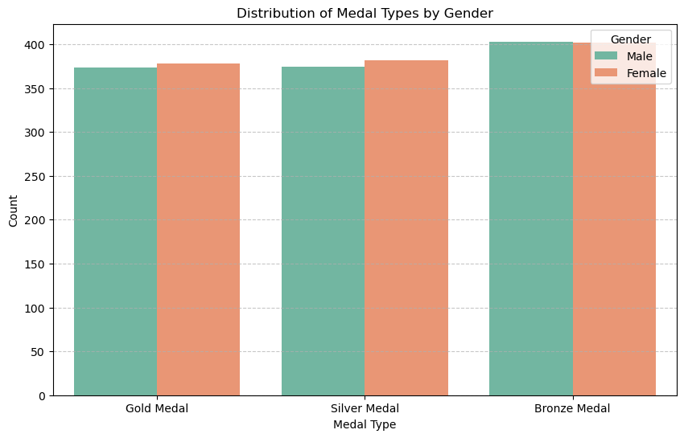

```python
## Distribution of Medal Types by Gender

plt.figure(figsize=(10, 6))
sns.countplot(x="medal_type", hue="gender", data=data, palette="Set2")
plt.title("Distribution of Medal Types by Gender")
plt.xlabel("Medal Type")
plt.ylabel("Count")
plt.legend(title="Gender")
plt.grid(True, axis='y', linestyle="--", alpha=0.7)
plt.xticks(rotation=0)
plt.show()
```

### Distribution of Medal Types by Gender

The bar chart shows the distribution of medal types (Gold, Silver, and Bronze) by gender. The chart reflects progress in achieving gender equality in sports, as both genders are equally competitive in winning medals.